# DICE Pre-Test

How Much Is Enough? Exploring Ad Exposure and Frequency Capping in Social Media Advertising

Authors

Affiliations

Hauke Roggenkamp

Institute of Behavioral Science and Technology, University of St. Gallen

Johannes Boegershausen

Rotterdam School of Management, Erasmus University

Christian Hildebrand

Institute of Behavioral Science and Technology, University of St. Gallen

Published

Thursday Jul 11, 2024, 18:49 GMT+2

While the effectiveness of repeated online advertisements tends to diminish as costs increase, online marketers often employ frequency caps in their campaigns. *Frequency Capping* refers to the practice of limiting the number of times a specific advertisement is shown to the same user within a set period. It is essential for preventing *ad fatigue* or *ad wear-out* (see, e.g., Pieters, Rosbergen, and Wedel 1999; Campbell and Keller 2003; Braun and Moe 2013; Silberstein, Shoham, and Klein 2023), where users become desensitized to an ad due to excessive ad exposure, which can limit an ad’s effectiveness and lead to diminished engagement rates as well as negative user experiences. This study mimics the practice of frequency capping in the context of social media advertising[^1] to better understand the relationship between (repetitive) ad exposure and recall, brand attitude and ad exposure duration as a proxy for (the absence of) attention.

We use DICE to mimic social media feeds with frequency capping. Specifically, we create a feed where organic posts and advertisements compete for the participant’s attention. By manipulating the frequency in which an advertisement is displayed within the feed, we study three facets of ad wear-out: learning, acceptance, and, to some degree, attention. To study learning, we elicit recall and measure how many ad exposures are required to *“cut through the content clutter”* (Ordenes et al. 2019). We investigate acceptance by focusing on brand attitude. Because the ads are displayed in an interactive social media feed, participants control the exposure duration the respective advertisement themselves. This offers them ways to adapt to repetition by reducing or increasing the duration of exposure to ads (Pieters, Rosbergen, and Wedel 1999, 424). We measure exposure duration, or *dwell time*, to investigate attention wear-out.

# Experimental Design

We create different feeds that contain both organic and sponsored posts as illustrated in Figure 1, where the first column on the left illustrates a feed without any repetition: it contains six organics posts, followed by one sponsored post (i.e., an ad) and 53 additional organic posts. The second column looks similar but displays the same sponsored post again with six organic posts in between. Moving from left to the right, the figure repeats the pattern: the sponsored post occurs increasingly more often.

We create eight feeds with a total of 60 posts and $N \in \{1, 2, 3, 4, 5, 6, 7, 8\}$ ad exposures, where we fully randomize the order of organic posts between-subjects.

Figure 1: Schematic Representation of Experimental Design with Feeds that Vary Ad Exposures

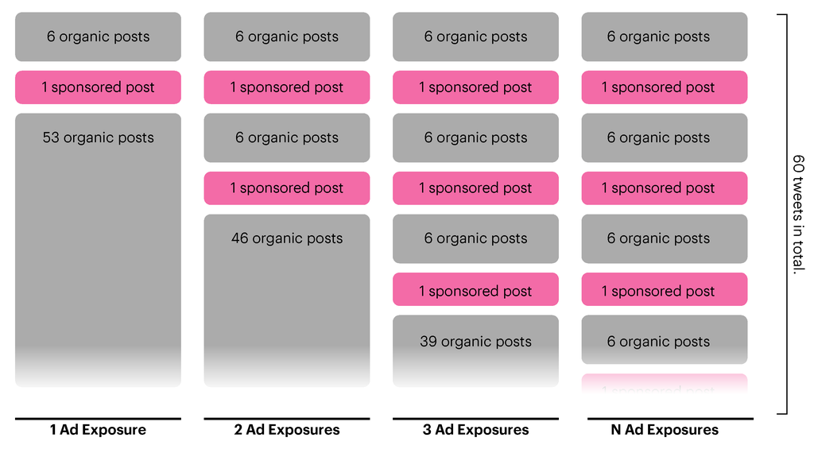

# Stimuli

The feed displays posts covering the [severe flooding](https://www.bbc.com/news/articles/cle07g0zzqeo) that affected Brazil earlier this year. Within this feed, we display a fictitious sponsored post by UNICEF[^2].

For this study, we created only one creative and one ad copy, which participants are exposed to up to eight times. The creative, depicted in Figure 2 is inspired by a [real sponsored post by UNICEF USA](https://www.facebook.com/ads/library/?id=500871092292935).

Figure 2: Sponsored Post

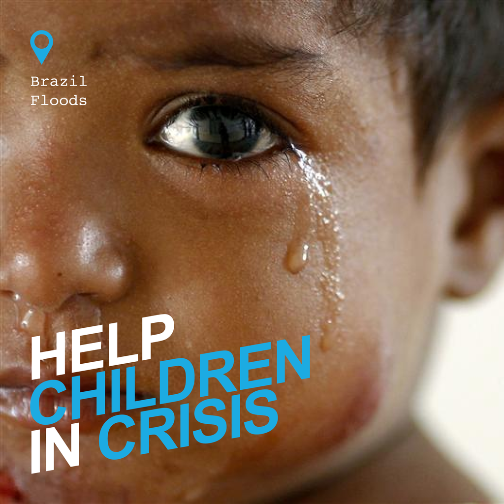

The copy stems from [another post by the same account](https://www.facebook.com/ads/library/?id=640842191548528) and reads:

> Wars. Climate change. Economic turmoil. Crisis after crisis is robbing children around the world of their lives and their futures. ENOUGH. NO MORE. Children need peace, NOW.

# Method and Procedure

We run a 8-cell between-subjects design in which a participant faces the sponsored post either 1, 2, …, 7 or 8 times.

After participants browse the social media feed, they are redirected to a Qualtrics survey that starts with basic demographic questions. Subsequently, they answer unaided and aided recall questions to indicate whether they remember seeing the ad. Finally, we measure brand attitudes before we debrief and redirect them to Prolific.

# Primary Analyses

Our primary interest lies in the effect the repetitive ad exposure has on two variables: (unaided) recall and brand attitude.

**Recall** We expect recall to increase in the number of ad exposures but expect diminishing marginal effects and a potential ceiling for high-exposure conditions. We test this using a simple logistic regression (where we may control for a set of covariates $\mathbf{X}$).

$$\text{recall} = \beta_0 + \beta_1 \text{ad exposure} + \beta_2\mathbf{X} + \epsilon$$

**Brand Attitude** The literature revealed a non-monotonic inverted-U relationship between exposure and affect toward the advertisement and has identified several factors that moderate the relationship (Pieters, Rosbergen, and Wedel 1999, 424), that is, a *wear-in* followed by a *wear-out* (Campbell and Keller 2003, 292). We ignore potential moderators and expect to estimate such a pattern using a simple OLS regression where $\beta_1 > 0$ and $\beta_2 < 0$.

$$\text{brand attitude} = \beta_0 + \beta_1 \text{ad exposure} + \beta_2\text{ad exposure}^2 + \epsilon$$

We measure brand attitude using Campbell and Keller (2003)’s four-item, seven-point differential scale, anchored by bad–good, low quality–high quality, unappealing–appealing, and unpleasant–pleasant. The four items are displayed in a random order. We average these items for our `brand_attitude` measure.

**Ad Attitude** Following Campbell and Keller (2003), we apply the same items, procedure, and analyses to the attitude towards the advertisement.

# Exploratory Analysis

We will also analyze DICE’s dwell time measure, i.e., the exposure duration participants allocate to individual posts. In addition, we measure whether participants click in a sponsored post. We expect very small click-through-rates that potentially diminish in ad exposures. We also use a deliberately vague open text field asking participants to *“[…] share your thoughts about the social media feed you just browsed (e.g., any aspects you particularly liked or disliked).”* We’ll analyze the responses using large language models and focus on preceptions of the feed, the brand, and the advertisements.

# Population

We will recruit participants from Prolific who meet the following criteria:

- Approval Rate >= 99%
- First Language == ‘English’
- Location == ‘USA’

In addition, we will exclude participants who participated in other DICE experiments.

# Sample Size & Recruitment

We expect the experiment to take 5 minutes on average and pay 0.80 GBP (i.e., 9.60 GBP/hr).

# Exclusion Criteria

We will only consider complete observations, that is, data from participants who browsed through the feed, answered the Qualtrics survey and who were redirected to Prolific with a functional completion code.

Because we gather process data, such as dwell time, we have tools to assess the data quality (Cuskley and Sulik) – at least during the exposure to the social media feed. If these data reveal inattentive participants, for instance, we may exclude them too but label the resulting analyses as exploratory.

# Prior Data Collection

We collected 72 observations before. However, a technical issue caused by too much strain on the database lead to a crash during the session. For this reason, we could not proceed with the data collection as planned. We will not include this data for future analyses.

## Procedure

Participants enter the experiment, submit a consent form and receive the following briefing:

> **Instructions** Welcome to our study covering a typical social media feed that focuses on the topic of *Brazil*. Please interact with the feed as you normally would on social media. Feel free to like, comment, or simply read through the posts according to your preference. Once you reach the end of the feed, you’ll find a button to proceed with the study. Click this button to move on to a series of short questions about your experience with the feed.

Subsequently, they browse the social media feed. You can browse an archived version of the feed with three ad exposures here.

Next, we direct participants to a Qualtrics survey that is displayed in the PDF[^4] below.

Finally, participants were redirected to Prolific to complete the study.

[figure not shown]

## References

Braun, Michael, and Wendy W. Moe. 2013. “Online Display Advertising: Modeling the Effects of Multiple Creatives and Individual Impression Histories.” *Marketing Science* 32 (5): 753–67. https://doi.org/10.1287/mksc.2013.0802.

Campbell, Margaret C., and Kevin Lane Keller. 2003. “Brand Familiarity and Advertising Repetition Effects.” *Journal of Consumer Research* 30 (2): 292–304. https://doi.org/10.1086/376800.

Cuskley, Christine, and Justin Sulik. “The Burden for High-Quality Online Data Collection Lies with Researchers, Not Recruitment Platforms.” *Perspectives on Psychological Science* 0 (0): 17456916241242734. https://doi.org/10.1177/17456916241242734.

Ordenes, Francisco Villarroel, Dhruv Grewal, Stephan Ludwig, Ko De Ruyter, Dominik Mahr, and Martin Wetzels. 2019. “Cutting Through Content Clutter: How Speech and Image Acts Drive Consumer Sharing of Social Media Brand Messages.” *Journal of Consumer Research* 45 (5): 988–1012. https://doi.org/10.1093/jcr/ucy032.

Pieters, Rik, Edward Rosbergen, and Michel Wedel. 1999. “Visual Attention to Repeated Print Advertising: A Test of Scanpath Theory.” *Journal of Marketing Research* 36 (4): 424–38. https://doi.org/10.1177/002224379903600403.

Silberstein, Natalia, Or Shoham, and Assaf Klein. 2023. “Combating Ad Fatigue via Frequency-Recency Features in Online Advertising Systems.” In *Proceedings of the 32nd ACM International Conference on Information and Knowledge Management*, 4822–28. CIKM ’23. New York, NY, USA: Association for Computing Machinery. https://doi.org/10.1145/3583780.3615461.

## Footnotes

[^1]: Within this context, we use the terms *ad* and *sponsored post* interchangeably.
[^2]: We acknowledge that UNICEF is a well known brand many participants are familiar with. This may lead to higher rates of recall but make the estimation of the effect the exposures have on attitude rather conservative (Campbell and Keller 2003).
[^3]: This way, we collect data in batches and reduce the load on the database.
[^4]: You can right-click and download it.